# Business Analytics Assignment - Automobile Data Analysis

Sakathevan Karththiga (JF/HDCSE/CMU/29/10)

2025-12-29

# Loading Required Libraries and Dataset

```r
# Load required libraries
library(ggplot2)
library(moments)

# Load the dataset
auto <- read.csv("/Users/shagevan/Desktop/BA_Automobile_Analytics/auto_Info.csv")

# View structure of data
str(auto)
```

```
## 'data.frame':    500 obs. of  8 variables:
##  $ engine_size    : num  2.25 1.93 2.32 2.76 1.88 ...
##  $ horsepower     : num  187 226.4 94.1 172.5 124 ...
##  $ curb_weight    : num  3700 3462 3030 2677 3349 ...
##  $ fuel_efficiency: num  28.9 22.2 20.9 25 24.1 ...
##  $ age            : int  13 14 5 10 2 7 2 13 11 12 ...
##  $ price          : num  28916 32899 32468 35891 33552 ...
##  $ vehicle_type   : chr  "Coupe" "Coupe" "SUV" "Hatchback" ...
##  $ brand          : chr  "Kia" "Ford" "Ford" "Toyota" ...
```

```r
head(auto)
```

```
##   engine_size horsepower curb_weight fuel_efficiency age    price vehicle_type
## 1    2.248357   187.0471    3699.678        28.89181  13 28915.91        Coupe
## 2    1.930868   226.3767    3462.317        22.24407  14 32899.26        Coupe
## 3    2.323844    94.0573    3029.815        20.90901   5 32467.67          SUV
## 4    2.761515   172.5188    2676.532        24.98313  10 35891.21    Hatchback
## 5    1.882923   123.9743    3349.112        24.14908   2 33551.68        Sedan
## 6    1.882932   130.5150    3196.743        22.73386   7 29852.16        Truck
##    brand
## 1    Kia
## 2   Ford
## 3   Ford
## 4 Toyota
## 5  Honda
## 6 Toyota
```

# Task 3: Central Tendency Analysis with Bell Curve Representation

## 3.1 Purpose of the Analysis

As a senior business analyst appointed by the Ministry of Transport, Highways, Ports and Civil Aviation Sri Lanka, this analysis applies central tendency measures such as the mean and median to key automobile attributes including engine size, horsepower, curb weight, and price in order to identify typical vehicle characteristics within the dataset.

## 3.2 Engine Size Analysis

```r
# Calculate central tendency measures
mean_engine <- mean(auto$engine_size)
median_engine <- median(auto$engine_size)
sd_engine <- sd(auto$engine_size)

cat("Engine Size Statistics:")
```

```
## Engine Size Statistics:
```

```r
cat("Mean:", round(mean_engine, 2), "litres")
```

```
## Mean: 2.01 litres
```

```r
cat("Median:", round(median_engine, 2), "litres")
```

```
## Median: 2.01 litres
```

```r
cat("Standard Deviation:", round(sd_engine, 2), "litres")
```

```
## Standard Deviation: 0.48 litres
```

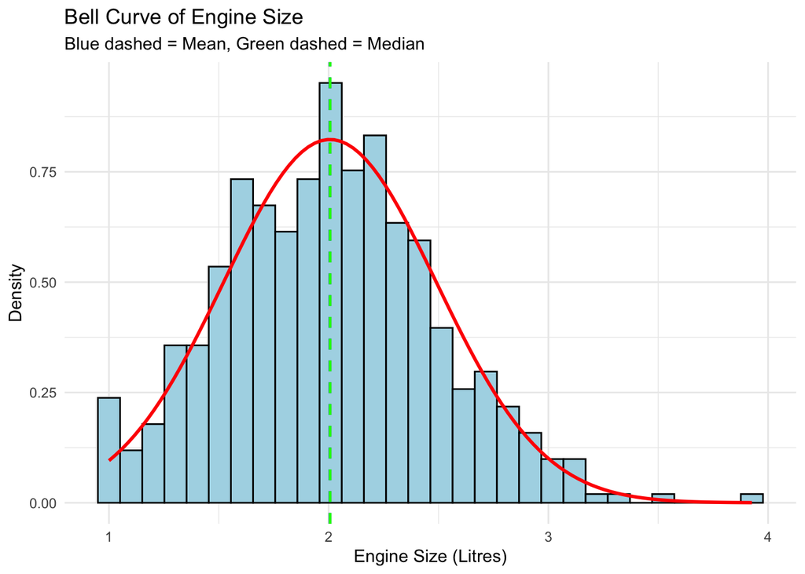

```r
# Bell Curve for Engine Size
ggplot(auto, aes(x = engine_size)) +
  geom_histogram(aes(y = after_stat(density)),
                 bins = 30,
                 fill = "lightblue",
                 color = "black") +
  stat_function(fun = dnorm,
                args = list(mean = mean_engine, sd = sd_engine),
                color = "red",
                linewidth = 1) +
  geom_vline(aes(xintercept = mean_engine), color = "blue", linetype = "dashed", linewidth = 0.8) +
  geom_vline(aes(xintercept = median_engine), color = "green", linetype = "dashed", linewidth = 0.8) +
  labs(title = "Bell Curve of Engine Size",
       subtitle = "Blue dashed = Mean, Green dashed = Median",
       x = "Engine Size (Litres)",
       y = "Density") +
  theme_minimal()
```

**Interpretation The closeness of the mean and median indicates a well-centred distribution. This suggests that moderate engine sizes dominate the dataset, supporting a balance between performance and fuel efficiency. Such vehicles are more suitable for Sri Lanka’s congested urban roads and mixed terrain, where excessive engine power is unnecessary.

## 3.3 Horsepower Analysis

```r
# Calculate central tendency measures
mean_hp <- mean(auto$horsepower)
median_hp <- median(auto$horsepower)
sd_hp <- sd(auto$horsepower)

cat("Horsepower Statistics:\n")
```

```
## Horsepower Statistics:
```

```r
cat("Mean:", round(mean_hp, 2), "hp\n")
```

```
## Mean: 151.5 hp
```

```r
cat("Median:", round(median_hp, 2), "hp\n")
```

```
## Median: 151.14 hp
```

```r
cat("Standard Deviation:", round(sd_hp, 2), "hp\n")
```

```
## Standard Deviation: 38.58 hp
```

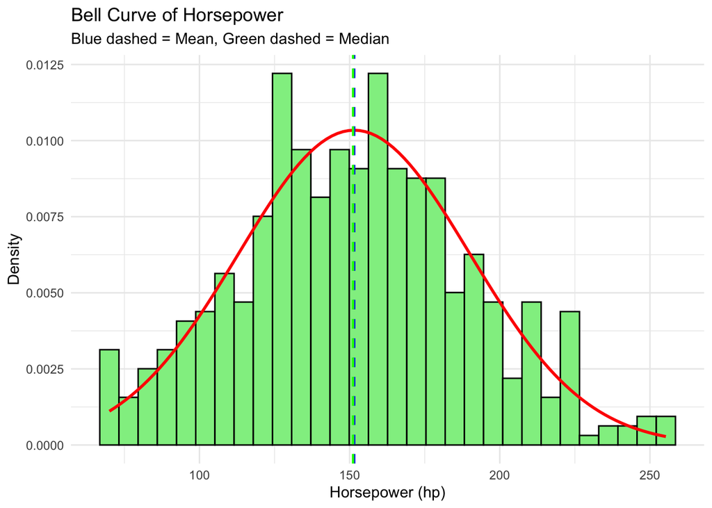

```r
# Bell Curve for Horsepower
ggplot(auto, aes(x = horsepower)) +
  geom_histogram(aes(y = after_stat(density)),
                 bins = 30,
                 fill = "lightgreen",
                 color = "black") +
  stat_function(fun = dnorm,
                args = list(mean = mean_hp, sd = sd_hp),
                color = "red",
                linewidth = 1) +
  geom_vline(aes(xintercept = mean_hp), color = "blue", linetype = "dashed", linewidth = 0.8) +
  geom_vline(aes(xintercept = median_hp), color = "green", linetype = "dashed", linewidth = 0.8) +
  labs(title = "Bell Curve of Horsepower",
       subtitle = "Blue dashed = Mean, Green dashed = Median",
       x = "Horsepower (hp)",
       y = "Density") +
  theme_minimal()
```

#Interpretation: The near-equality of the mean and median reflects a stable central tendency. Moderate horsepower levels support safer driving and controlled vehicle handling, which are important for Sri Lanka’s narrow roads and varying traffic conditions.

## 3.4 Curb Weight Analysis

```r
# Calculate central tendency measures
mean_weight <- mean(auto$curb_weight)
median_weight <- median(auto$curb_weight)
sd_weight <- sd(auto$curb_weight)

cat("Curb Weight Statistics:")
```

```
## Curb Weight Statistics:
```

```r
cat("Mean:", round(mean_weight, 2), "lbs")
```

```
## Mean: 3057.94 lbs
```

```r
cat("Median:", round(median_weight, 2), "lbs")
```

```
## Median: 3059.9 lbs
```

```r
cat("Standard Deviation:", round(sd_weight, 2), "lbs")
```

```
## Standard Deviation: 496.07 lbs
```

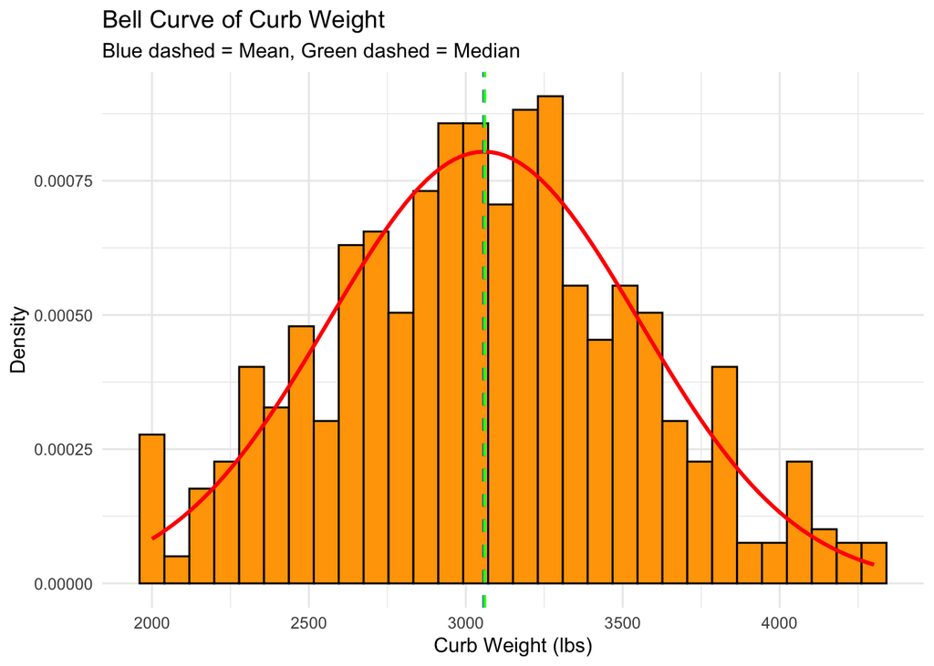

```r
# Bell Curve for Curb Weight
ggplot(auto, aes(x = curb_weight)) +
  geom_histogram(aes(y = after_stat(density)),
                 bins = 30,
                 fill = "orange",
                 color = "black") +
  stat_function(fun = dnorm,
                args = list(mean = mean_weight, sd = sd_weight),
                color = "red",
                linewidth = 1) +
  geom_vline(aes(xintercept = mean_weight), color = "blue", linetype = "dashed", linewidth = 0.8) +
  geom_vline(aes(xintercept = median_weight), color = "green", linetype = "dashed", linewidth = 0.8) +
  labs(title = "Bell Curve of Curb Weight",
       subtitle = "Blue dashed = Mean, Green dashed = Median",
       x = "Curb Weight (lbs)",
       y = "Density") +
  theme_minimal()
```

## 3.5 Price Analysis

```r
# Calculate central tendency measures
mean_price <- mean(auto$price)
median_price <- median(auto$price)
sd_price <- sd(auto$price)

cat("Price Statistics:\n")
```

```
## Price Statistics:
```

```r
cat("Mean: USD", round(mean_price, 2), "")
```

```
## Mean: USD 33068.88
```

```r
cat("Median: USD", round(median_price, 2), "")
```

```
## Median: USD 32765.19
```

```r
cat("Standard Deviation: USD", round(sd_price, 2), "")
```

```
## Standard Deviation: USD 6298.51
```

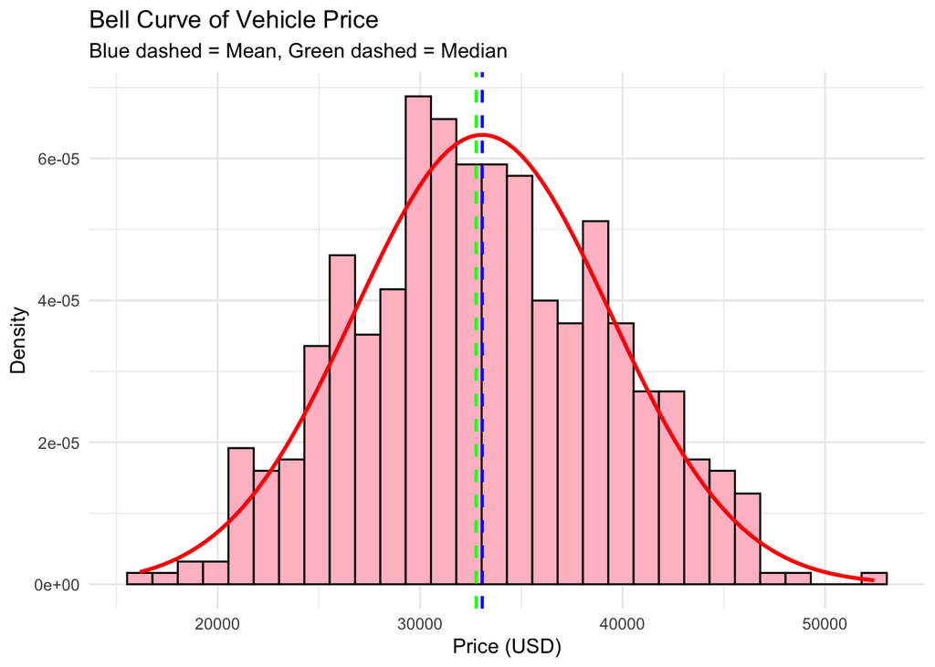

```r
# Bell Curve for Price
ggplot(auto, aes(x = price)) +
  geom_histogram(aes(y = after_stat(density)),
                 bins = 30,
                 fill = "pink",
                 color = "black") +
  stat_function(fun = dnorm,
                args = list(mean = mean_price, sd = sd_price),
                color = "red",
                linewidth = 1) +
  geom_vline(aes(xintercept = mean_price), color = "blue", linetype = "dashed", linewidth = 0.8) +
  geom_vline(aes(xintercept = median_price), color = "green", linetype = "dashed", linewidth = 0.8) +
  labs(title = "Bell Curve of Vehicle Price",
       subtitle = "Blue dashed = Mean, Green dashed = Median",
       x = "Price (USD)",
       y = "Density") +
  theme_minimal()
```

#Interpretation: Since the mean is slightly higher than the median, the distribution indicates the presence of higher-priced vehicles influencing the average. In this case, the median provides a more representative measure of typical vehicle cost, supporting fair pricing, taxation, and vehicle import policy decisions.

## 3.6 Skewness Analysis

```r
# Calculate skewness for all variables
skew_engine <- skewness(auto$engine_size, na.rm = TRUE)
skew_engine
```

```
## [1] 0.2676726
```

```r
skew_hp <- skewness(auto$horsepower, na.rm = TRUE)
skew_hp
```

```
## [1] 0.1390291
```

```r
skew_weight <- skewness(auto$curb_weight, na.rm = TRUE)
skew_weight
```

```
## [1] 0.07649933
```

```r
skew_price <- skewness(auto$price, na.rm = TRUE)
skew_price
```

```
## [1] 0.09369872
```

#Interpretation: All variables exhibit positive skewness, indicating right-tailed distributions. Among them, engine size has the highest positive skewness, suggesting a slightly longer right tail due to a small number of vehicles with larger engines. However, the skewness values for all variables are relatively low (close to 0), confirming that the distributions are approximately symmetric. Therefore, the mean and median are reliable measures of central tendency, and the bell curves appropriately represent the underlying data.

# Task 4: Statistical Hypothesis Analysis – Vehicle Price vs Vehicle Type

## 4.1 Objective

This analysis examines whether vehicle price significantly fluctuates based on vehicle type using One-Way Analysis of Variance (ANOVA).

## 4.2 Hypothesis Statements

Null Hypothesis (H0): There is no statistically significant difference in the mean vehicle price across different vehicle types.

Alternative Hypothesis (H1):There is a statistically significant difference in the mean vehicle price among different vehicle types.

Significance Level: 0.05

## 4.3 ANOVA Test

```r
# One-Way ANOVA Test
anova_result <- aov(price ~ vehicle_type, data = auto)
anova_summary <- summary(anova_result)
print(anova_summary)
```

```
##               Df    Sum Sq  Mean Sq F value Pr(>F)
## vehicle_type   5 3.350e+08 66994440   1.701  0.133
## Residuals    494 1.946e+10 39394689
```

```r
# Extract F-value and p-value
f_value <- anova_summary[[1]]$`F value`[1]
p_value_anova <- anova_summary[[1]]$`Pr(>F)`[1]

cat("\n--- ANOVA Results ---\n")
```

```
##
## --- ANOVA Results ---
```

```r
cat("F-value:", round(f_value, 3), "\n")
```

```
## F-value: 1.701
```

```r
cat("p-value:", round(p_value_anova, 4), "\n")
```

```
## p-value: 0.1328
```

```r
# Decision
alpha <- 0.05

if (p_value_anova < alpha) {
  cat("Decision: Reject H0")
  cat("Conclusion: There IS a statistically significant difference in mean vehicle prices across vehicle types")
} else {
  cat("Decision: Fail to Reject H0")
  cat("Conclusion: There is NO statistically significant difference in mean vehicle prices across vehicle types")
}
```

```
## Decision: Fail to Reject H0Conclusion: There is NO statistically significant difference in mean vehicle prices across vehicle types
```

#Statistical Interpretation: The ANOVA test produced an F-value of 1.701 with a p-value of 0.133. Since the p-value (0.133) is greater than the significance level (0.05), we fail to reject the null hypothesis. This indicates that there is no statistically significant difference in mean vehicle prices across different vehicle types in the dataset.

## 4.4 Graphical Analysis

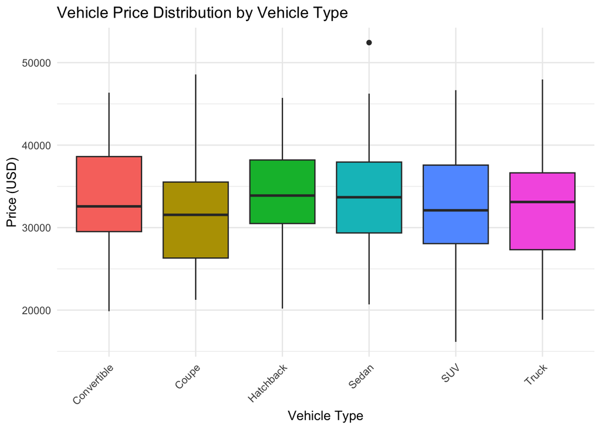

```r
# Box Plot of Price by Vehicle Type
ggplot(auto, aes(x = vehicle_type, y = price, fill = vehicle_type)) +
  geom_boxplot() +
  labs(title = "Vehicle Price Distribution by Vehicle Type",
       x = "Vehicle Type",
       y = "Price (USD)") +
  theme_minimal() +
  theme(legend.position = "none",
        axis.text.x = element_text(angle = 45, hjust = 1))
```

#Graphical Interpretation: The box plot illustrating vehicle price distributions across vehicle types shows overlapping price ranges and similar median values among categories. Although some vehicle types display slightly higher price variability, the substantial overlap among groups visually supports the ANOVA result that price differences are not statistically significant.

# Task 5: Statistical Relationship Analysis between Vehicle Price and Other Features

## 5.1 Objective

This analysis determines whether statistically significant relationships exist between vehicle price and key vehicle characteristics: engine size, horsepower, curb weight, and vehicle age.

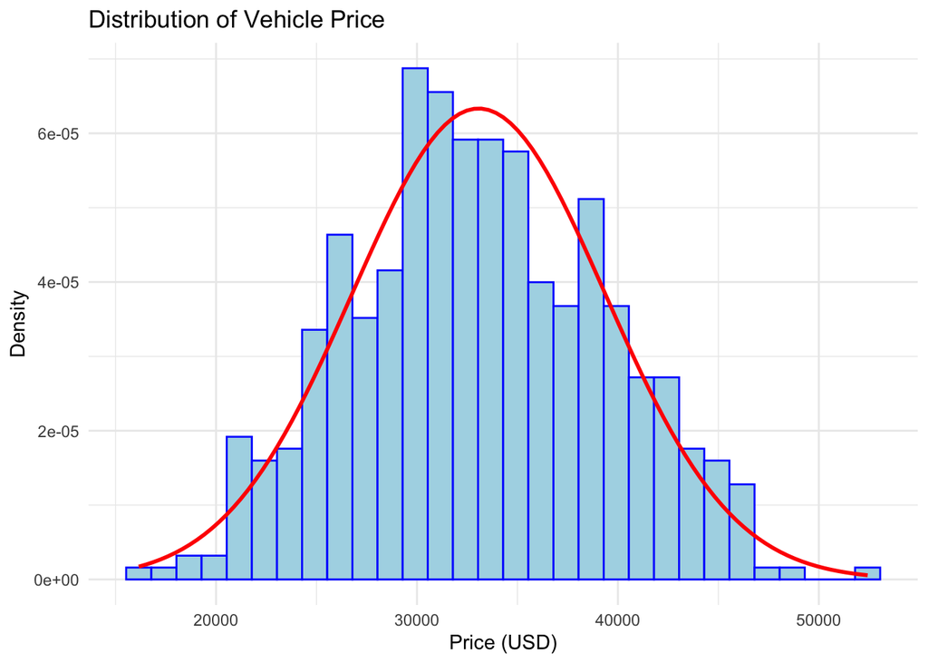

```r
# Distribution of Vehicle Price (Graphical Normality Check)
ggplot(auto, aes(x = price)) +
  geom_histogram(aes(y = after_stat(density)),
                 bins = 30,
                 fill = "lightblue",
                 color = "blue") +
  stat_function(fun = dnorm,
                args = list(mean = mean(auto$price),
                            sd = sd(auto$price)),
                color = "red",
                linewidth = 1) +
  labs(title = "Distribution of Vehicle Price",
       x = "Price (USD)",
       y = "Density") +
  theme_minimal()
```

#Normality Interpretation: Normality was assessed using histogram and bell curve visualisation. The graphical analysis shows that vehicle price follows an approximately normal distribution, with the histogram closely following the bell curve pattern. Due to the large sample size (n ≈ 500), the Central Limit Theorem applies, allowing the use of parametric inferential tests. Therefore, Pearson correlation was selected as an appropriate method to examine linear relationships between vehicle price and other features.

## 5.3 Correlation Analysis and Hypothesis Testing

### 5.3.1 Vehicle Price vs Engine Size

Null Hypothesis (H0):There is no statistically significant linear relationship between vehicle price and engine size.

Alternative Hypothesis (H1):There is a statistically significant linear relationship between vehicle price and engine size.

```r
# Correlation test: Price vs Engine Size
x <- auto$engine_size
y <- auto$price

test_engine <- cor.test(x, y)
print(test_engine)
```

```
##
##  Pearson's product-moment correlation
##
## data:  x and y
## t = 4.1541, df = 498, p-value = 3.844e-05
## alternative hypothesis: true correlation is not equal to 0
## 95 percent confidence interval:
##  0.09686834 0.26641956
## sample estimates:
##       cor
## 0.1830044
```

```r
cat("Summary ")
```

```
## Summary
```

```r
cat("Correlation Coefficient (r):", round(test_engine$estimate, 4), "")
```

```
## Correlation Coefficient (r): 0.183
```

```r
cat("p-value:", format(test_engine$p.value, scientific = TRUE, digits = 4), "")
```

```
## p-value: 3.844e-05
```

```r
cat(" 95% Confidence Interval:", round(test_engine$conf.int[1], 4), "to", round(test_engine$conf.int[2], 4), "")
```

```
##  95% Confidence Interval: 0.0969 to 0.2664
```

```r
alpha <- 0.05
if (test_engine$p.value < alpha) {
  cat("Decision: Reject H0 ")
  cat("Conclusion: There IS a significant linear relationship between price and engine size.")
} else {
  cat("Decision: Fail to Reject H0")
  cat("Conclusion: There is NO significant linear relationship between price and engine size.")
}
```

```
## Decision: Reject H0 Conclusion: There IS a significant linear relationship between price and engine size.
```

#Correlation Interpretation

The Pearson correlation coefficient (r = 0.183) indicates a weak positive linear relationship between vehicle price and engine size. The p-value (3.844e-05) is less than 0.05, so the null hypothesis is rejected. This confirms a statistically significant positive relationship between vehicle price and engine size.

#Regression Analysis:

```r
# Simple Linear Regression
model_engine <- lm(y ~ x)
summary(model_engine)
```

```
##
## Call:
## lm(formula = y ~ x)
##
## Residuals:
##      Min       1Q   Median       3Q      Max
## -15438.5  -4361.0   -345.7   4618.6  18762.4
##
## Coefficients:
##             Estimate Std. Error t value Pr(>|t|)
## (Intercept)  28297.7     1181.5  23.950  < 2e-16 ***
## x             2378.6      572.6   4.154 3.84e-05 ***
## ---
## Signif. codes:  0 '***' 0.001 '**' 0.01 '*' 0.05 '.' 0.1 ' ' 1
##
## Residual standard error: 6198 on 498 degrees of freedom
## Multiple R-squared:  0.03349,    Adjusted R-squared:  0.03155
## F-statistic: 17.26 on 1 and 498 DF,  p-value: 3.844e-05
```

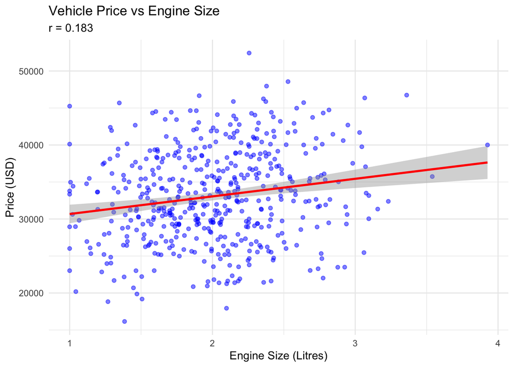

```r
# Scatter plot with regression line
ggplot(auto, aes(x = engine_size, y = price)) +
  geom_point(alpha = 0.5, color = "blue") +
  geom_smooth(method = "lm", se = TRUE, color = "red") +
  labs(title = "Vehicle Price vs Engine Size",
       subtitle = paste("r =", round(test_engine$estimate, 3)),
       x = "Engine Size (Litres)",
       y = "Price (USD)") +
  theme_minimal()
```

#Interpretation: The Pearson correlation coefficient (r = 0.183) indicates a weak positive linear relationship between vehicle price and engine size. Since the p-value (3.84e-05) is less than 0.05, the null hypothesis is rejected. The regression model shows that for every 1 litre increase in engine size, vehicle price increases by approximately USD 2,378.60. The R-squared value (0.0335) indicates that 3.35% of the variation in price is explained by engine size. Although this is a weak model, the relationship is statistically significant.

### 5.3.2 Vehicle Price vs Horsepower

**Null Hypothesis (H0): There is no statistically significant linear relationship between vehicle price and horsepower.

**Alternative Hypothesis (H1): There is a statistically significant linear relationship between vehicle price and horsepower.

```r
# Correlation test: Price vs Horsepower
x <- auto$horsepower
y <- auto$price

test_hp <- cor.test(x, y)
print(test_hp)
```

```
##
##  Pearson's product-moment correlation
##
## data:  x and y
## t = 16.805, df = 498, p-value < 2.2e-16
## alternative hypothesis: true correlation is not equal to 0
## 95 percent confidence interval:
##  0.5424763 0.6547057
## sample estimates:
##       cor
## 0.6015511
```

```r
cat(" Summary ")
```

```
##  Summary
```

```r
cat("Correlation Coefficient (r):", round(test_hp$estimate, 4), "\n")
```

```
## Correlation Coefficient (r): 0.6016
```

```r
cat("p-value:", format(test_hp$p.value, scientific = TRUE, digits = 4), "\n")
```

```
## p-value: 1.57e-50
```

```r
cat("95% Confidence Interval:", round(test_hp$conf.int[1], 4), "to", round(test_hp$conf.int[2], 4), "\n")
```

```
## 95% Confidence Interval: 0.5425 to 0.6547
```

```r
if (test_hp$p.value < alpha) {
  cat("\nDecision: Reject H0\n")
  cat("Conclusion: There IS a significant linear relationship between price and horsepower.\n")
} else {
  cat("\nDecision: Fail to Reject H0\n")
  cat("Conclusion: There is NO significant linear relationship between price and horsepower.\n")
}
```

```
##
## Decision: Reject H0
## Conclusion: There IS a significant linear relationship between price and horsepower.
```

#Interpretation The Pearson correlation coefficient (r = 0.602) indicates a moderate positive linear relationship between vehicle price and horsepower. The p-value (1.57e-50) is less than 0.05, so the null hypothesis is rejected. This confirms a statistically significant positive relationship between vehicle price and horsepower.

#Regression Analysis

```r
# Simple Linear Regression
model_hp <- lm(y ~ x)
summary(model_hp)
```

```
##
## Call:
## lm(formula = y ~ x)
##
## Residuals:
##      Min       1Q   Median       3Q      Max
## -15648.7  -3671.8   -282.8   3884.2  12613.3
##
## Coefficients:
##              Estimate Std. Error t value Pr(>|t|)
## (Intercept) 18188.599    913.682   19.91   <2e-16 ***
## x              98.217      5.845   16.80   <2e-16 ***
## ---
## Signif. codes:  0 '***' 0.001 '**' 0.01 '*' 0.05 '.' 0.1 ' ' 1
##
## Residual standard error: 5037 on 498 degrees of freedom
## Multiple R-squared:  0.3619, Adjusted R-squared:  0.3606
## F-statistic: 282.4 on 1 and 498 DF,  p-value: < 2.2e-16
```

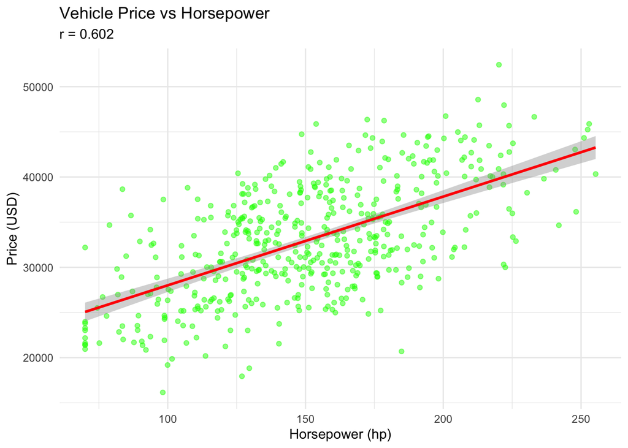

```r
# Scatter plot with regression line
ggplot(auto, aes(x = horsepower, y = price)) +
  geom_point(alpha = 0.5, color = "green") +
  geom_smooth(method = "lm", se = TRUE, color = "red") +
  labs(title = "Vehicle Price vs Horsepower",
       subtitle = paste("r =", round(test_hp$estimate, 3)),
       x = "Horsepower (hp)",
       y = "Price (USD)") +
  theme_minimal()
```

#Interpretation The Pearson correlation coefficient indicates a moderate positive linear relationship between vehicle price and horsepower. Since the p-value is less than 0.05, the null hypothesis is rejected. The regression model confirms that as horsepower increases, vehicle price also increases. The R-squared value indicates that a good proportion of variation in price is explained by horsepower. Higher-powered vehicles command higher prices due to enhanced performance.

### 5.3.3 Vehicle Price vs Curb Weight

Null Hypothesis (H0): There is no statistically significant linear relationship between vehicle price and curb weight.

Alternative Hypothesis (H1): There is a statistically significant linear relationship between vehicle price and curb weight.

```r
# Correlation test: Price vs Curb Weight
x <- auto$curb_weight
y <- auto$price

test_weight <- cor.test(x, y)
print(test_weight)
```

```
##
##  Pearson's product-moment correlation
##
## data:  x and y
## t = -2.6328, df = 498, p-value = 0.008731
## alternative hypothesis: true correlation is not equal to 0
## 95 percent confidence interval:
##  -0.20277331 -0.02978148
## sample estimates:
##        cor
## -0.1171661
```

```r
cat("\n--- Summary ---\n")
```

```
##
## --- Summary ---
```

```r
cat("Correlation Coefficient (r):", round(test_weight$estimate, 4), "\n")
```

```
## Correlation Coefficient (r): -0.1172
```

```r
cat("p-value:", format(test_weight$p.value, scientific = TRUE, digits = 4), "\n")
```

```
## p-value: 8.731e-03
```

```r
cat("95% Confidence Interval:", round(test_weight$conf.int[1], 4), "to", round(test_weight$conf.int[2], 4), "\n")
```

```
## 95% Confidence Interval: -0.2028 to -0.0298
```

```r
if (test_weight$p.value < alpha) {
  cat("\nDecision: Reject H0\n")
  cat("Conclusion: There IS a significant linear relationship between price and curb weight.\n")
} else {
  cat("\nDecision: Fail to Reject H0\n")
  cat("Conclusion: There is NO significant linear relationship between price and curb weight.\n")
}
```

```
##
## Decision: Reject H0
## Conclusion: There IS a significant linear relationship between price and curb weight.
```

#Interpretation The Pearson correlation coefficient (r = -0.117) indicates a weak negative linear relationship between vehicle price and curb weight. The p-value (0.0087) is less than 0.05, so the null hypothesis is rejected. This confirms a statistically significant negative relationship between vehicle price and curb weight.

#Regression Analysis

```r
# Simple Linear Regression
model_weight <- lm(y ~ x)
summary(model_weight)
```

```
##
## Call:
## lm(formula = y ~ x)
##
## Residuals:
##    Min     1Q Median     3Q    Max
## -16481  -4077   -443   4446  18780
##
## Coefficients:
##              Estimate Std. Error t value Pr(>|t|)
## (Intercept) 37617.961   1750.389  21.491  < 2e-16 ***
## x              -1.488      0.565  -2.633  0.00873 **
## ---
## Signif. codes:  0 '***' 0.001 '**' 0.01 '*' 0.05 '.' 0.1 ' ' 1
##
## Residual standard error: 6261 on 498 degrees of freedom
## Multiple R-squared:  0.01373,    Adjusted R-squared:  0.01175
## F-statistic: 6.932 on 1 and 498 DF,  p-value: 0.008731
```

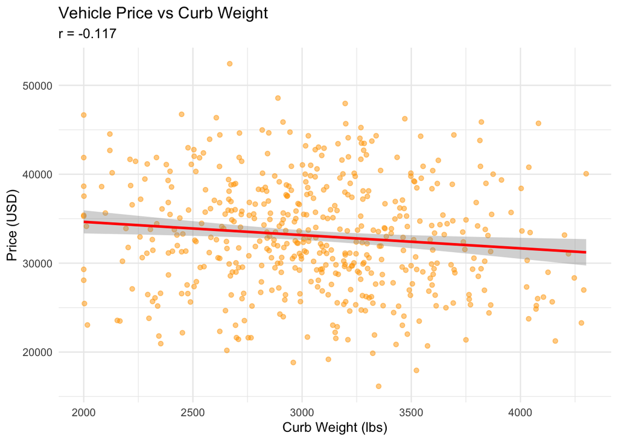

```r
# Scatter plot with regression line
ggplot(auto, aes(x = curb_weight, y = price)) +
  geom_point(alpha = 0.5, color = "orange") +
  geom_smooth(method = "lm", se = TRUE, color = "red") +
  labs(title = "Vehicle Price vs Curb Weight",
       subtitle = paste("r =", round(test_weight$estimate, 3)),
       x = "Curb Weight (lbs)",
       y = "Price (USD)") +
  theme_minimal()
```